# Estadística para el análisis político II - Migración a nivel mundial

Los ciudadanos de un país se ven constantemente influenciados por el entorno en el que viven. Por ende, siempre buscarán aquel lugar donde puedan percibir una mayor seguridad u oportunidades para su desarrollo y el de sus seres queridos. Especialmente, resulta común el poder pensar que personas de países subdesarrollados o en vías de desarrollo sean los que se encuentren más motivados a migrar por las condiciones estructurales e institucionales de sus países.

Como resultado, en el presente reporte, se busca analizar las razones que pueden haber influenciado la migración a nivel global para el año 2022. Esto en aras a entender los posibles factores que afectan de forma negativa la percepción por parte de la ciudadanía de un país en particular, lo cual resulta en la migración de sus ciudadanos. Para ello, se analizarán si ciertas variables, desde el índice de la percepción de corrupción hasta la desigualdad económica, resultan fundamentales para explicar el fenómeno. En el proceso, se han realizado regresiones lineales para determinar cómo diferentes modelos con diferentes factores funcionan. Asimismo, se presentan técnicas para explicar las variables a utilizar y poder determinar cuáles de ellas resultan parecidas entre sí y afecten similarmente a la variable latente. Finalmente, se presenta un análisis de conglomerados para visualizar la similitud entre los países presentados, y que puedan poseer características similares. Ello permite entender qué países son los que pueden poseer políticas o niveles de calidad de vida parecidas y en la forma en la que puedan afectar a la población.

Finalmente, a partir del análisis, se busca dar mayores luces respecto a esta problemática para, a partir de las variables examinadas, pensar qué estrategias de acción podrían implementar los países, desde su propia particularidad nacional, para evitar la pérdida de ciudadanos y posible capital humano.

A continuacion se muestra un resumen de las variables a utilizar y casos del estudio:

|  | ISO | pais | Migracion_2022 | Criminalidad | PCorrupcion_2021 | Desempleo_2021 | PBI_2020 | E2: Economic Inequality | EmisionesCO2 | Paz | Catastrofe |
| --- | --- | --- | --- | --- | --- | --- | --- | --- | --- | --- | --- |
| 1 | AFG | Afghanistan | -0.10 | 7.08 | 16 | 13.283 | -4.57503186 | 8.1 | 0.15982437 | 3.600 | 5 |
| 2 | AGO | Angola | -0.19 | 5.29 | 29 | 8.530 | -8.49308612 | 8.9 | 0.79213707 | 2.025 | 5 |
| 3 | ALB | Albania | -3.23 | 5.63 | 35 | 11.819 | -2.92582096 | 2.9 | 1.69224832 | 1.769 | 5 |
| 4 | ARE | United Arab Emirates | -3.45 | 5.75 | 69 | 3.358 | -7.27217297 | 3.3 | 19.32956328 | 1.890 | 5 |
| 5 | ARG | Argentina | -0.08 | 4.38 | 38 | 10.902 | -10.76510773 | 4.9 | 3.74065029 | 1.931 | 1 |
| 6 | ARM | Armenia | -5.36 | 3.26 | 49 | 20.897 | -7.57206053 | 3.6 | 2.08606068 | 2.016 | 5 |
| 7 | AUS | Australia | 6.93 | 4.00 | 73 | 5.112 | -1.27852628 | 1.8 | 15.23826715 | 1.485 | 3 |
| 8 | AUT | Austria | 3.55 | 4.04 | 74 | 6.301 | -7.12092797 | 2.3 | 7.29398425 | 1.318 | 5 |
| 9 | AZE | Azerbaijan | 0.00 | 5.08 | 30 | 6.583 | -4.95270174 | 5.1 | 3.54239783 | 2.286 | 5 |
| 10 | BDI | Burundi | 7.09 | 4.51 | 19 | 1.792 | -2.71202474 | 7.2 | 0.06244267 | 2.409 | 5 |

[output cut: 137 more lines]

### 1. Regresiones

Primera regresion

|  | Regresion 1 |
| --- | --- |
| (Intercept) | 0.863 |
|  | (1.341) |
| EmisionesCO2 | 0.155* |
|  | (0.064) |
| E2 × Economic Inequality | -0.087 |
|  | (0.148) |
| Criminalidad | -0.261 |
|  | (0.250) |
| Num.Obs. | 147 |
| R2 | 0.091 |
| R2 Adj. | 0.072 |
| AIC | 752.4 |
| BIC | 767.3 |
| Log.Lik. | -371.176 |
| F | 4.753 |
| RMSE | 3.02 |

+ p < 0.1, * p < 0.05, ** p < 0.01, *** p < 0.001

Segunda regresion

|  | Regresion 2 |
| --- | --- |
| (Intercept) | 4.487** |
|  | (1.501) |
| Catastrofe | -0.572+ |
|  | (0.296) |
| Paz | -1.069+ |
|  | (0.558) |
| Num.Obs. | 147 |
| R2 | 0.070 |
| R2 Adj. | 0.057 |
| AIC | 753.7 |
| BIC | 765.7 |
| Log.Lik. | -372.860 |
| F | 5.385 |
| RMSE | 3.06 |

+ p < 0.1, * p < 0.05, ** p < 0.01, *** p < 0.001

Tercera regresion

|  | Regresion 3 |
| --- | --- |
| (Intercept) | -2.657*** |
|  | (0.779) |
| PCorrupcion_2021 | 0.056*** |
|  | (0.014) |
| Desempleo_2021 | -0.045 |
|  | (0.042) |
| PBI_2020 | -0.062 |
|  | (0.041) |
| Num.Obs. | 147 |
| R2 | 0.129 |
| R2 Adj. | 0.111 |
| AIC | 746.0 |
| BIC | 760.9 |
| Log.Lik. | -367.982 |
| F | 7.081 |
| RMSE | 2.96 |

+ p < 0.1, * p < 0.05, ** p < 0.01, *** p < 0.001

En primer lugar,podemos ver que la regresión es válida a partir del anova (p-value < 0.05). Sin embargo, el modelo solo explica en un 11% a la variable dependiente, lo cual es un valor bajo. La única variable significativa (al 0.05) para el modelo es la Percepción de la corrupción. A su vez, es una relación directa debido a que el coeficiente es positivo:la magnitud de ese efecto es 0.056, lo que indica cuanto aumenta la cantidad de personas que migran por cada 1000 habitantes (variable dependiente) *en promedio* cuando la Percepción de la Corrupción en el país se incrementa en una unidad.

Regresion total

|  | Regresion conjunta |
| --- | --- |
| (Intercept) | -2.854 |
|  | (3.264) |
| PCorrupcion_2021 | 0.058* |
|  | (0.026) |
| Desempleo_2021 | -0.043 |
|  | (0.043) |
| PBI_2020 | -0.060 |
|  | (0.041) |
| E2 × Economic Inequality | 0.256 |
|  | (0.188) |
| Criminalidad | 0.035 |
|  | (0.308) |
| EmisionesCO2 | 0.119+ |
|  | (0.064) |
| Paz | 0.009 |
|  | (0.804) |
| Catastrofe | -0.413 |
|  | (0.302) |
| Num.Obs. | 147 |
| R2 | 0.165 |
| R2 Adj. | 0.117 |
| AIC | 749.8 |
| BIC | 779.7 |
| Log.Lik. | -364.913 |
| F | 3.407 |
| RMSE | 2.90 |

+ p < 0.1, * p < 0.05, ** p < 0.01, *** p < 0.001

### 2. Fórmula de la regresión:

Ya aplicando todas las variables, vemos que, si bien la variable corrupción ha perdido significancia a comparación del modelo anterior, continúa explicando la variable dependiente. Esta vez, al 0.05. Además, señalamos que la variable EmisionesCO2 es significativa al 0.1. En general, este modelo puede explicar un 11% de la hipótesis. Dicho valor es el mismo que se obtenía al utilizar la corrupción, el desempleo y el PBI. En conclusión, este modelo final, que acopla toda las variables, junto al tercer modelo, explican de mejor manera la hipótesis a comparación de los dos primeros.

```
##
## =====================================================================================================================
##                                                               Dependent variable:
##                           -------------------------------------------------------------------------------------------
##                                                                 Migracion_2022
##                                    (1)                    (2)                    (3)                    (4)
## ---------------------------------------------------------------------------------------------------------------------
## Constant                          0.863                 4.487***              -2.657***                -2.854
##                                  (1.341)                (1.501)                (0.779)                (3.264)
##
## EmisionesCO2                     0.155**                                                               0.119*
##                                  (0.064)                                                              (0.064)
##
## `E2: Economic Inequality`         -0.087                                                               0.256
##                                  (0.148)                                                              (0.188)
##
## Criminalidad                      -0.261                                                               0.035
##                                  (0.250)                                                              (0.308)
##
## Catastrofe                                              -0.572*                                        -0.413
##                                                         (0.296)                                       (0.302)
##
## Paz                                                     -1.069*                                        0.009
##                                                         (0.558)                                       (0.804)
##
## PCorrupcion_2021                                                               0.056***               0.058**
##                                                                                (0.014)                (0.026)
##
## Desempleo_2021                                                                  -0.045                 -0.043
##                                                                                (0.042)                (0.043)
##
## PBI_2020                                                                        -0.062                 -0.060
##                                                                                (0.041)                (0.041)
##
## ---------------------------------------------------------------------------------------------------------------------
## Observations                       147                    147                    147                    147
## R2                                0.091                  0.070                  0.129                  0.165
## Adjusted R2                       0.072                  0.057                  0.111                  0.117
## Residual Std. Error          3.064 (df = 143)       3.089 (df = 144)       2.999 (df = 143)       2.989 (df = 138)
## F Statistic               4.753*** (df = 3; 143) 5.385*** (df = 2; 144) 7.081*** (df = 3; 143) 3.407*** (df = 8; 138)
## =====================================================================================================================
## Note:                                                                                     *p<0.1; **p<0.05; ***p<0.01
```

### 3. Análisis factorial exploratorio

Elaboramos una matriz de correlación con las variables:

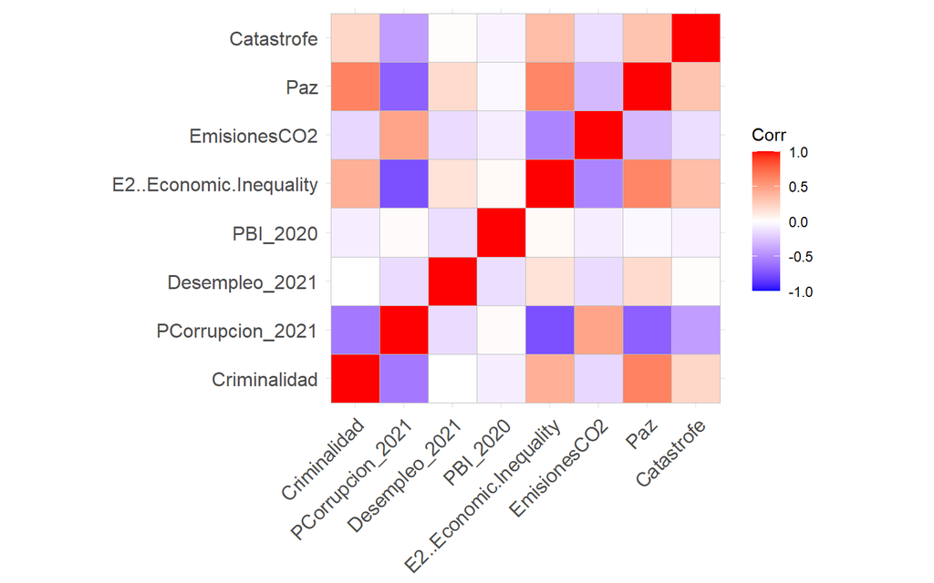

Observamos que los cuadros se pintan completamente de rojo en donde las variables coinciden, pues, al representar lo mismo, se encuentran perfectamente correlacionadas. Esta es la entrada para la realización del EFA.

Ahora, verificamos si los datos nos permitirán factorizar:

```
## Kaiser-Meyer-Olkin factor adequacy
## Call: psych::KMO(r = corMatrix)
## Overall MSA =  0.79
## MSA for each item =
##            Criminalidad        PCorrupcion_2021          Desempleo_2021
##                    0.74                    0.79                    0.53
##                PBI_2020 E2..Economic.Inequality            EmisionesCO2
##                    0.43                    0.80                    0.81
##                     Paz              Catastrofe
##                    0.82                    0.84
```

Vemos que el Overall MSA es de 0.79. Al ser un valor superior a 0.6, podemos afirmar que aporta al análisis.

Por su parte, sobre cada variable independiente, observamos lo siguiente: Teniendo en cuenta el valor de 0.6 como punto de corte, las variables que menos aportan al EFA son “Desempleo_2021” y “PBI_2020”. Por el contrario, los indicadores que más aporte ofrecen son “E2..Economic.Inequality”, “Emisiones de CO2”, “Paz” y “Catastrofe”.

Como parte del proceso, también se evaluaron las pruebas de matriz de identidad y matriz de singularidad. Así pues, los resultados de ambas pruebas dieron resultado negativo. Ello indica que, en la matriz de identidad, las variables evaluadas poseen una correlación consigo mismas. En el caso de la matriz de singularidad, nos permite entender que posee una matriz inversa; por ende, se puede realizar el análisis.

Es relevante señalar que, pese a que la normalización de las variables no es exigida para la elaboración del EFA, en el presente trabajo, se decide optar por ella. Esto obedece a un motivo específico: Sin realizarla, el número de factores que se nos sugiere para redimensionar la base de datos es 1. Dicha alternativa no aporta a nuestra investigación. Con las variables normalizadas, observamos que se nos sugiere dividir las variables en dos factores.

```
##
## Loadings:
##                         MR1    MR2
## Criminalidad             0.314  0.742
## PCorrupcion_2021        -0.794 -0.443
## Desempleo_2021           0.199
## PBI_2020                       -0.114
## E2..Economic.Inequality  0.852  0.204
## EmisionesCO2            -0.636
## Paz                      0.566  0.593
## Catastrofe               0.274  0.183
##
##                  MR1   MR2
## SS loadings    2.296 1.193
## Proportion Var 0.287 0.149
## Cumulative Var 0.287 0.436
```

Vemos que, en el proceso de redimensionar 8 variables a 2, se ha logrado recuperar casi el 44% de información.

Sobre las variables independientes, tenemos lo siguiente: Tanto “Criminalidad” como “P.Corrupción_2021”, “E2..Economic.Inequality”, “Paz” y “Catastrofe” aparecen en ambos factores. Sin embargo, estableceremos 0.5 como un punto de corte para determinar a qué factor corresponderá cada componente. En los casos de desempleo, pbi y emisiones de co2, encerramos que los tres indicadores solamente pertenecen a un factor: el segundo y el primero respectivamente.

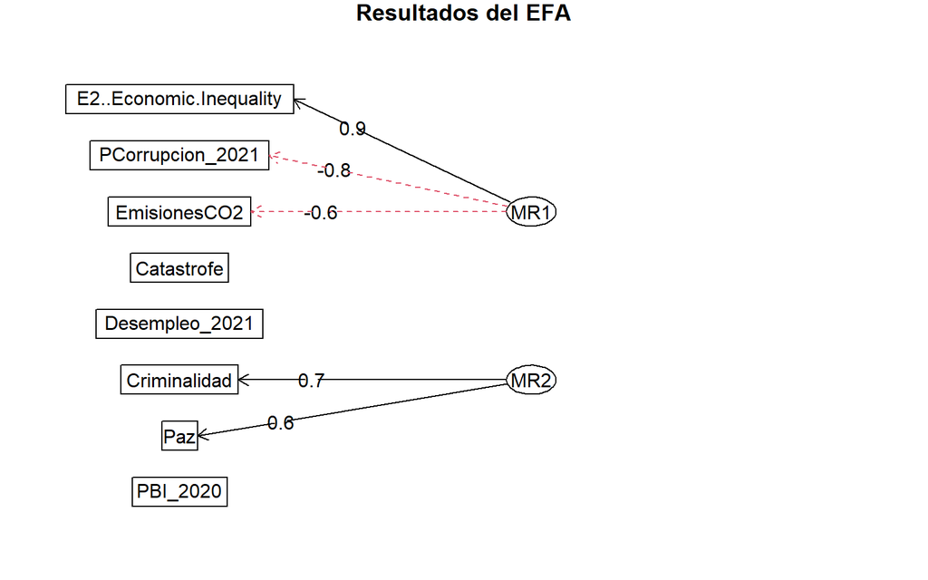

Luego de elaborar el corte, damos cuenta de que “Desempleo_2021”, “PBI_2020” y “Catastrofe” ya no se encuentran en ningún factor. Esto debido a que las tres variables contaban con valores inferiores a 0.5. En cuanto a las demás variables, todas han sido ubicadas en un solo factor con excepción de “Paz”, pues los dos valores que presenta se encuentran por encima del punto de corte. No obstante, en el siguiente grafico, la variable mencionada fue seleccionada para el segundo factor.

A continuación, se realizan las pruebas de comunalidad y de complejidad.

|  | x |
| --- | --- |
| PBI_2020 | 0.0148403 |
| Desempleo_2021 | 0.0396734 |
| Catastrofe | 0.1082818 |
| EmisionesCO2 | 0.4114279 |
| Criminalidad | 0.6491047 |
| Paz | 0.6714058 |
| E2..Economic.Inequality | 0.7674431 |
| PCorrupcion_2021 | 0.8272648 |

En esta primera, observamos que las variables independientes que más han contribuído a los factores son “Criminalidad”, “Paz”, “E2..Economic.Inequality” y “PCorrupción_2021”.

|  | x |
| --- | --- |
| Desempleo_2021 | 1.002771 |
| EmisionesCO2 | 1.032348 |
| E2..Economic.Inequality | 1.114685 |
| PBI_2020 | 1.276106 |
| Criminalidad | 1.346253 |
| PCorrupcion_2021 | 1.566976 |
| Catastrofe | 1.742484 |
| Paz | 1.995570 |

En cuanto a la complejidad de las variables, es relevante señalar que “Paz”, así como contribuye a los factores, también presenta tal complejidad que se acerca a más de uno. Otros componentes que también demuestran complejidad son “Catastrofe” y, en menor medida, “PCorrupción_2021”.

A continuación, observamos los valores proyectados de ambos factores.

| MR1 | MR2 |
| --- | --- |
| 1.2558079 | 1.7737211 |
| 1.2183249 | -0.3744655 |
| -0.3492012 | 0.2334893 |
| -1.8601879 | 0.8852160 |
| 0.4567235 | -0.3636323 |
| -0.0960993 | -0.9977052 |

### 4. Análisis de conglomerados

Para el trabajo de aglomeración o clusterización, se emplearon seis de las ocho variables. Se optó por eliminar las variables “Percepción de la corrupción” y “Desastres naturales” debido a que dificultan realizar una interpretación coherente; es decir, impiden establecer, a fines de interpretación, una jerarquización entre los conglomerados de los países.

La técnica de jerarquización divisiva (Diana) fue la escogida para el proceso de clusterización debido a que cuenta con el mayor promedio de siluetas (0.27) en comparación a la técnia de partición y jerarquización aglomerativa, cuyas siluetas promedio son 0.24 y 0.23 respectivamente. Asimismo, es importante acotar que, si bien el estadístico gap sugiere que la cantidad óptima de aglomerados o clusters para el modelo es uno (1), se decidió utilizar tres clusters debido a que permite una mejor interpretación y diferenciación visual entre los países. Aquella decisión fue tomada en base a la leve variación en el promedio de las siluetas de la técnica Diana, la cual pasó de 0.31 con dos clusters a 0.27 con tres clusters. El modelo, a su vez, cuenta únicamente con seis países mal clusterizados:Uruguay, Bangladesh, Mongolia, Bhutan, Lithuania y Latvia. En tanto es una cantidad reducida de países, el modelo sugiere ser el más apropiado. Aquello se puede apreciar en el tercer grafico mostrado a continuación.

Clusterización via PAM

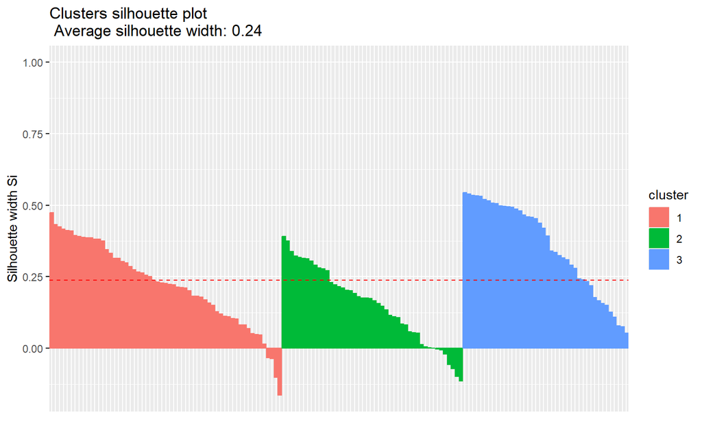

Clusterización via AGNES

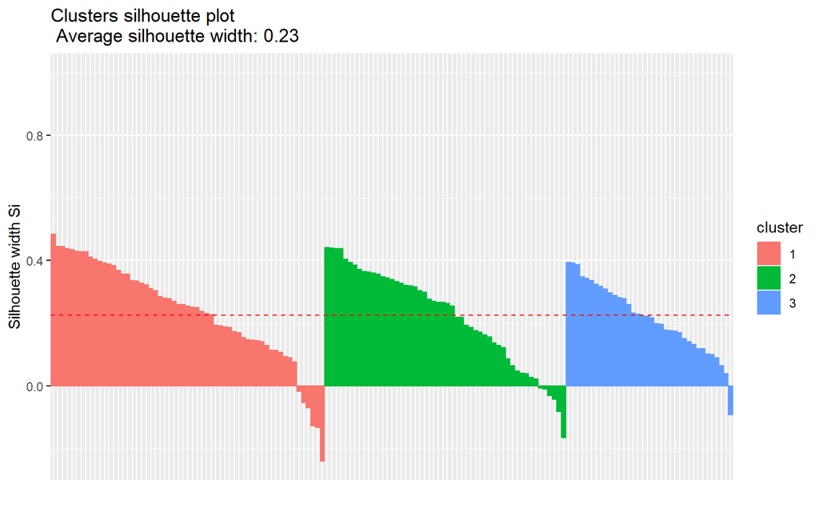

Clusterización via Diana:

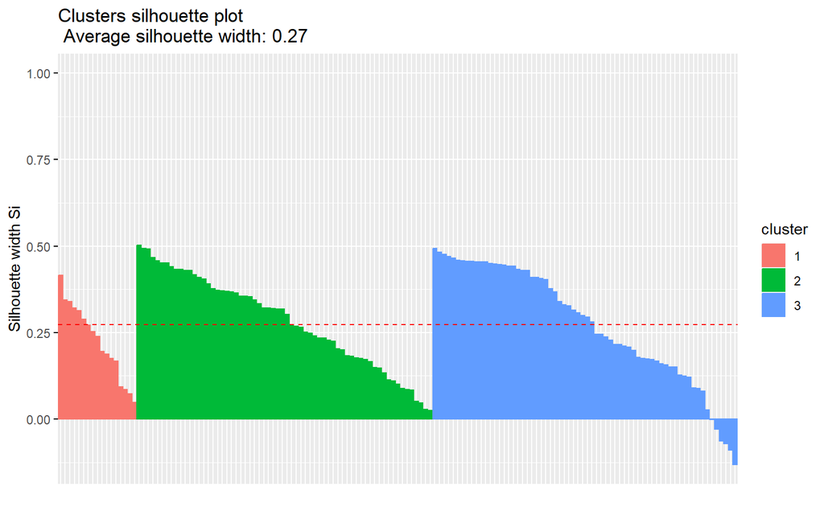

|  | Criminalidad | Desempleo_2021 | PBI_2020 | E2: Economic Inequality | EmisionesCO2 | Paz | diana |
| --- | --- | --- | --- | --- | --- | --- | --- |
| Afghanistan | 7.08 | 13.283 | -4.5750319 | 8.1 | 0.1598244 | 3.600 | 1 |
| Angola | 5.29 | 8.530 | -8.4930861 | 8.9 | 0.7921371 | 2.025 | 2 |
| Albania | 5.63 | 11.819 | -2.9258210 | 2.9 | 1.6922483 | 1.769 | 3 |
| United Arab Emirates | 5.75 | 3.358 | -7.2721730 | 3.3 | 19.3295633 | 1.890 | 3 |
| Argentina | 4.38 | 10.902 | -10.7651077 | 4.9 | 3.7406503 | 1.931 | 3 |
| Armenia | 3.26 | 20.897 | -7.5720605 | 3.6 | 2.0860607 | 2.016 | 3 |
| Australia | 4.00 | 5.112 | -1.2785263 | 1.8 | 15.2382672 | 1.485 | 3 |
| Austria | 4.04 | 6.301 | -7.1209280 | 2.3 | 7.2939843 | 1.318 | 3 |
| Azerbaijan | 5.08 | 6.583 | -4.9527017 | 5.1 | 3.5423978 | 2.286 | 2 |
| Burundi | 4.51 | 1.792 | -2.7120247 | 7.2 | 0.0624427 | 2.409 | 2 |
| Benin | 5.25 | 1.574 | 1.0900985 | 8.2 | 0.6185837 | 2.123 | 2 |
| Burkina Faso | 5.49 | 4.758 | -0.9071605 | 7.8 | 0.2460462 | 2.543 | 2 |
| Bangladesh | 4.98 | 5.229 | 2.4158552 | 5.7 | 0.5565295 | 2.077 | 2 |
| Bulgaria | 5.43 | 5.424 | -3.8115159 | 3.8 | 5.6108573 | 1.562 | 3 |
| Bosnia and Herzegovina | 5.89 | 15.215 | -2.5232973 | 4.1 | 6.3829180 | 1.860 | 3 |

| diana | Criminalidad | Desempleo_2021 | PBI_2020 | E2: Economic Inequality | EmisionesCO2 | Paz |
| --- | --- | --- | --- | --- | --- | --- |
| 1 | 6.843529 | 13.712588 | -7.211020 | 6.864706 | 3.380905 | 2.924941 |
| 2 | 5.458437 | 7.225984 | -4.099230 | 6.795312 | 1.481291 | 2.151172 |
| 3 | 4.538788 | 8.041151 | -4.896579 | 3.346970 | 6.631193 | 1.693288 |

Finalmente, el modelo establece tres grupos de países según sus niveles de criminalidad, desempleo, crecimiento económico, desigualdad, niveles de contaminación (a partir de la camtidad de emisiones de dióxido de carbono) y niveles de deterioro de la paz. El grupo “1” comprende a los países que, a nivel general, presentan los peores niveles en las variables anteriormente mencionadas, a excepción de los niveles de contaminación por emisiones de CO2. El grupo “2”, por su parte, comprende a los países que presentan niveles intermedios de criminalidad, desigualdad y deterioro de la paz. Respecto al nivel de desempleo y crecimiento del PBI, estos países cuentan los niveles más bajos entre los tres grupos, pese a que la diferencia con el grupo “3” no es tan lejana. Aquello es especialmente relevante en los niveles de decrecimiento económico ya que la diferencia entre los países del grupo “2” y “3” es, en promedio, menor a 1 punto.Finalmente, los países del grupo “3” son los que cuentan con los niveles más bajos de criminalidad, desigualdad y deterioro de la paz. Si bien han tenido un decrecimiento del PBI ligeramente mayor a los países del grupo “2”, sus niveles de desigualdad son menores (la mitad de aquellos) lo cual es importante de analizar ya que, como sugieren autores como Thomas Picketty (2013), indicadores como el PBI pueden nignorar aspectos relevantes de una sociedad como la distribución de la riqueza. Es importante acotar que los tres grupos presentan un decrecimiento en sus niveles de PBI, siendo los países del grupo 1 los que tienen los niveles más preocupantes. Aquello puede estar relacionado a la crisis que generó la pandemia por el COVID-19 en el 2020, año del cual se tomó la información. En aquel contexto, los países del grupo 1 mostraron ser los más vulnerables ante la crisis. Por otra parte, los altos niveles de emisiones de CO2 de los países del grupo “3” pueden estar relacionados al nivel de desarrollo de su industria.

### 5. Análisis geoespacial de clusters:

A continuación, se presenta de forma gráfica los grupos de países anteriormente desarrollados. El grupo 3 está conformdo por 66 países, el grupo 2 por 64 países y el grupo 1 por 17 países.

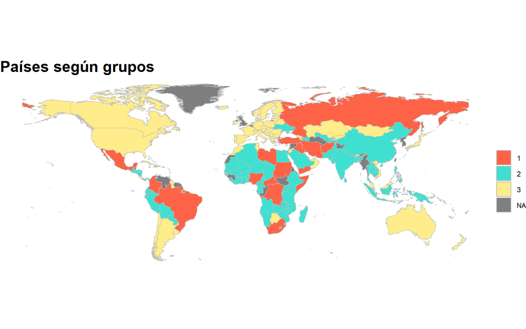

Como se puede apreciar, el grupo 3 está conformado en su mayoría por los países de América del Norte, Europa y Oceanía. También estan presenten ciertos países de América latina como Argentina, Chile y Uruguay, y algunos países de África y Asia como Botswana, Mongolia y Kazhahistan, pero son una minoría. Por su parte, los países del grupo 2 y 1 son mayoritariamente africanos, asiáticos y latinoamericanos (especialmente de Centro y Suramérica). En África, predominan los países del grupo 2, aunque también hay una presencia relevante de países del grupo 1. En Medio Oriente, por su parte, predominan los países del grupo 1. Los países de Asia, por otro lado, pertenecen en su mayoría al grupo 2, aunque varios países relativamente pequeños son parte del grupo 3, tendencia que podría seguir aumentando con la emergencia de los “tigres asiáticos”. Finalmente, América latina es una región dividida: los países se dividen entre los tres grupos.Por ejemplo, Brasil, Colombia y México pertenecen al grupo 1;Ecuador, Perú, Bolivia y Paraguay pertenecen al grupo 2; y Argentina, Chiley Uruguay pertenecen al grupo 3.

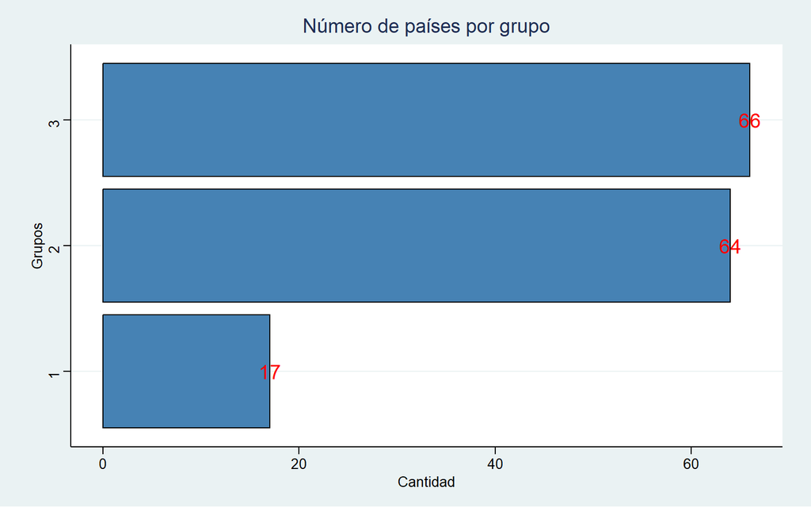

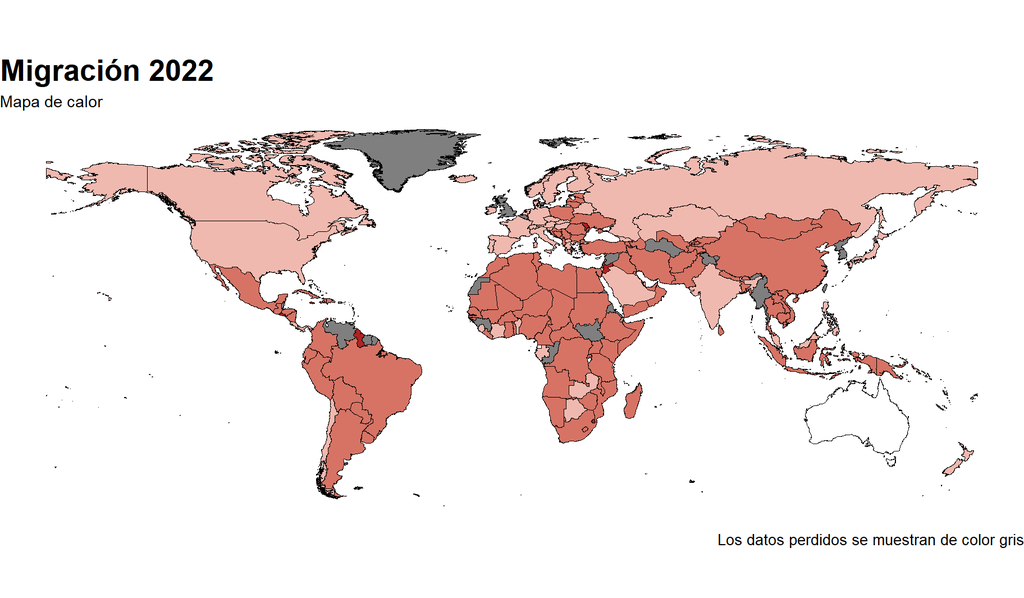